# Daffa Daniel Rivaldi

[LinkedIn](https://www.linkedin.com/in/daffadr/) [Github](https://github.com/daffadaniel) [Medium](https://medium.com/@daffadaniel16)

Highly motivated and detail-oriented student with interest in data analysis, statistical modeling, and data science. Proficient in utilizing tools such as Python, Git, PostgreSQL, and Tableau to solve complex problems and deliver actionable insights. Strong foundation in mathematics with a proven abilty to collaborate and execute projects effectively. Currently focused on improving data analysis skill, mastering machine learning, and improving databases management skills.

## Education

- **Universitas Indonesia**  
  Bachelor’s degree, Mathematics | Aug 2021 – Sept 2025
- **SMA Negeri 1 Tangerang**  
  Mathematics and Natural Science | Jul 2017 – May 2020

## Certifications & Training

- **Machine Learning APIs & Machine Learning Deployments**  
  Pacmann Academy | Issued August 2025  
  [Credential](https://sertifikat.pacmann.ai/GTkjy5cSsh1C6kj)
- **Customer, Marketing, Product Analytics & Experimentation**  
  Pacmann Academy | Issued April 2025  
  [Credential](https://sertifikat.pacmann.ai/9nsLonSnORdLs78)
- **Basic & Advanced Machine Learning Algorithm**  
  Pacmann Academy | Issued January 2025  
  [Credential](https://sertifikat.pacmann.ai/GjzLZYElj6EVtQg)
- **SQL & Relational Database**  
  Pacmann Academy | Issued November 2024  
  [Credential](https://sertifikat.pacmann.ai/3Ug0yzxDi4ckMRc)
- **Data Visualization & Wrangling**  
  Pacmann Academy | Issued September 2024  
  [Credential](https://sertifikat.pacmann.ai/YodhlXoXm9u06zc)
- **Basic Python Programming & Python for Software Engineering**  
  Pacmann Academy | Issued July 2024  
  [Credential](https://sertifikat.pacmann.ai/Bvcu7xU41qZHd0x)

## Language

- **Indonesian** (Native)
- **English**  
  Duolingo English Test | Issued Jan 2024 – Expires Jan 2026  
  [Credential](https://certs.duolingo.com/d6b44791c6555007900d2d951368ab5e)

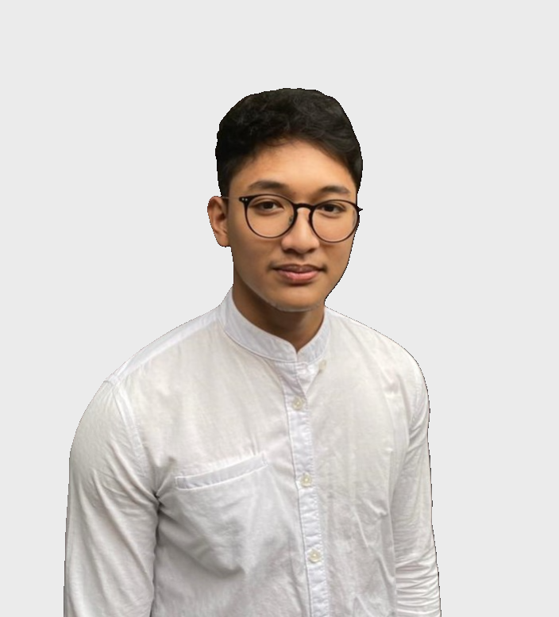